# 2020005_hypothalamus-circadian-investigation-rna-seq_Zhang

Jiayu Zhang

4/5/2020

# Hypothalamus Investigation Group Comparison

> general data structure  
> differential expressed genes (control group vs. exercise group) t-test? orthologs of mouse circadian genes in rats subset the differential expressed genes – circadian and exercise

### set up the environment

```r
################################################################################
##### Resources and Dependencies ###############################################
################################################################################

# Set the working directory
WD <- '/Volumes/SanDisk64GB/MoTrPAC/'
setwd(WD)

# Load dependencies
pacs...man <- c("tidyverse","GenomicRanges", "DESeq2","devtools","rafalib","GO.db","vsn","hexbin","ggplot2",
               "GenomicFeatures","Biostrings","BSgenome","AnnotationHub","plyr","dplyr",
               "org.Rn.eg.db","pheatmap","sva","formula.tools","pathview","biomaRt","feather",
               "PROPER","SeqGSEA",'purrr','BioInstaller','RColorBrewer','lubridate', "hms","ggpubr", "ggrepel",
               "AnnotationDbi")

if (!requireNamespace("BiocManager", quietly = TRUE))
  install.packages("BiocManager")

BiocManager::install("PROPER")
BiocManager::install("org.Rn.eg.db")
BiocManager::install("pcaExplorer")
mypackages = c("tidyverse","GenomicRanges", "DESeq2","devtools","ggplot2","dplyr","PROPER", "lubridate", "hms",
               "org.Rn.eg.db", "AnnotationDbi", "pcaExplorer", "pheatmap")
lapply(mypackages, FUN = function(X) {
  do.call("library", list(X)) })
```

[output not shown]

[output cut: 146 more lines]

```r
############################################################
##### Functions ############################################
############################################################

# Set select
select <- dplyr::select

# Capture the Date and Author
################################################################################
date <- format.Date( Sys.Date(), '%Y%m%d' )
auth <- "Jiayu"
################################################################################
```

## Data structure

### Load and clean data

- Data file to load:
  - Standford batch 2 & metadata & phenotype

```r
# Stanford batch 2 read counts (320 samples in total; 80 hypothalamus samples)
sford_2 <- read.table(file = paste0(WD,'Data/rna-seq/stanford/batch_2/summary/rsem_genes_count.txt'),
                      header = T, row.names = 1, na.strings = "NA", check.names = F)  %>% as.matrix()

# Stanford batch 2 meta data
sford_meta_2 <-  read.csv(file = paste0(WD,'Data/rna-seq/stanford/batch_2/metadata/sample_metadata_20191010.csv'),
                          header = T, na.strings = "NA", check.names = F)

# Merged Phenotype
###################################

load(paste0(WD,"Data/phenotype/merged/merged_dmaqc_data2019-10-13.Rdata"))

# Mice RNA seq library
###################################

# circadian genes
# TODO: may need to find orthologs for rats
mice_cir_genes = read.csv(file = paste0(WD,'Data/library/20080516_mouse-SCN-circadian-genes_yan.csv'),
                            header = T, na.strings = "NA", check.names = F)
mice_cir_genes = mice_cir_genes[-which(is.na(mice_cir_genes$SCN)),]

# Convert counts to integers
mode(sford_2) <- "integer"

# Adjust column objects
########################
# To factors

sford_meta_2$vial_label = as.factor(sford_meta_2$vial_label)
factor_cols <- c("labelid",
                 "viallabel",
                 "animal.registration.sex")
for(fc in factor_cols){
  merged_dmaqc_data[[fc]] <- as.factor(merged_dmaqc_data[[fc]])
}

# To Dates: 03JUL2018
date_cols <- c("acute.test.d_visit",
               "acute.test.d_start",
               "animal.familiarization.d_visit",
               "animal.familiarization.d_treadmillbegin",
               "animal.familiarization.d_treadmillcomplete",
               "animal.registration.d_visit",
               "animal.registration.d_arrive",
               "animal.registration.d_reverselight",
               "specimen.collection.d_visit")
for(dc in date_cols){
  merged_dmaqc_data[[dc]] <- dmy(merged_dmaqc_data[[dc]])
}
# To Dates: Jan 2018
merged_dmaqc_data <- merged_dmaqc_data %>%
  mutate(animal.registration.d_birth = dmy(paste0('1 ',animal.registration.d_birth)))

# To Times: 10:30:00
time_cols <- c("acute.test.t_complete",
               "specimen.collection.t_anesthesia",
               "specimen.collection.t_bloodstart",
               "specimen.collection.t_bloodstop",
               "specimen.collection.t_edtafill",
               "specimen.collection.uteruscomplete",
               "specimen.collection.t_uterusstart",
               "specimen.collection.t_uterusstop",
               "specimen.collection.t_death",
               "specimen.processing.t_collection",
               "specimen.processing.t_edtaspin",
               "specimen.processing.t_freeze")
for(tc in time_cols){
  merged_dmaqc_data[[tc]] <- merged_dmaqc_data[[tc]] %>% as.character() %>% parse_time()
}

# To Times: 01:21
merged_dmaqc_data <- merged_dmaqc_data %>%
  mutate(acute.test.howlongshock =
           ifelse((merged_dmaqc_data$acute.test.howlongshock != ''), paste0('00:',acute.test.howlongshock), '00:00:00'))
merged_dmaqc_data$acute.test.howlongshock <- parse_time(merged_dmaqc_data$acute.test.howlongshock)

# Adjust labels within columns (e.g. 1 and 2 to female and male)
# see ../phenotype/merged/20191013_merged-column-dictionary_steep-edits.xlsx
########################
merged_dmaqc_data <- merged_dmaqc_data %>%
  mutate(animal.registration.sex =
           case_when(animal.registration.sex == '1' ~ 'Female',
                     animal.registration.sex == '2' ~ 'Male'))
merged_dmaqc_data$animal.registration.sex <- as.factor(merged_dmaqc_data$animal.registration.sex)

#' ### Incorporate Annotation from Phenotypic Data
#'

################################################################################
######### Incorporate Phenotypic Annotations ###################################
################################################################################

# Replace the name of the vial label column (for sake of join)
names(merged_dmaqc_data) <- str_replace(names(merged_dmaqc_data), 'viallabel', 'vial_label')

# Perform a left join to incorporate phenotypic information
status <- left_join(sford_meta_2, merged_dmaqc_data, by = 'vial_label') %>% as.data.frame()
#dim(status)

# Adjust objects in columns as needed

# Create new columns
status <- status %>%
  mutate(Seq_batch =
           case_when((GET_site == 'Stanford' & Seq_date == '190426') ~ "Stanford_1",
                     (GET_site == 'Stanford' & Seq_date == '190703') ~ "Stanford_2",
                     (GET_site == 'MSSM' & Seq_date == '190409') ~ "MSSM_1",
                     (GET_site == 'MSSM' & Seq_date == '190626') ~ "MSSM_2",
                     (GET_site == 'MSSM' & Seq_date == '190723') ~ "MSSM_3")
  )
#table(status$Seq_batch)

# To factors
factor_cols <- "Seq_batch"
for(fc in factor_cols){
  status[[fc]] <- as.factor(status[[fc]])
}

# "It is absolutely critical that the columns of the count matrix and the rows of the
# column data (information about samples) are in the same order. DESeq2 will not make
# guesses as to which column of the count matrix belongs to which row of the column data,
# these must be provided to DESeq2 already in consistent order." ~ Mike Love

# TODO: Come back and figure out about missing samples and annotation

# Make sure that all values in status "sample_key" are unique
#status$sample_key %>% length()
#status$sample_key %>% unique %>% length()
# Make sure that all columns in counts matrix are unique
#colnames(all.data.m) %>% length()
#colnames(all.data.m) %>% unique %>% length()

rownames(status) <- status$vial_label
#all(rownames(status) %in% colnames(all.data.m))
#all(colnames(all.data.m) %in% rownames(status))
#all(rownames(status) == colnames(all.data.m))
#all.data.m <- all.data.m[, rownames(status)]
status$animal.key.anirandgroup = as.factor(status$animal.key.anirandgroup)
# add a new column to status dataframe to differentiate time in hour in a day
status$hour_death = hour(status$specimen.collection.t_death) %>% as.factor()
table(status$hour_death)
```

```
##
##  9 10 11 12 13 14 16 17
## 20 44 44 20 60 60 20 44
```

```r
#hist(as.numeric(status$hour_death))
```

### PCA Visualization

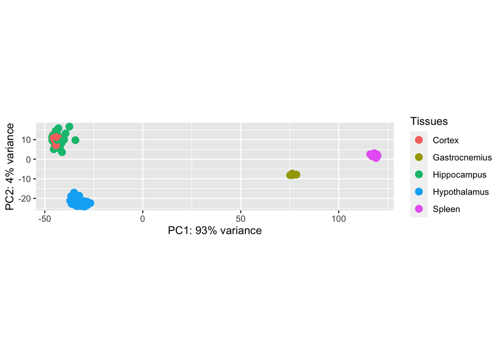

```r
count_data = sford_2[, sort(colnames(sford_2))]
col_data = status[sort(rownames(status)), ]
design = ~1
title = paste0('Design: ',as.character(design))
# Create a DESeqDataSet Object
dds <- DESeqDataSetFromMatrix(countData = count_data,
                              colData = col_data,
                              design = design)


# Filter genes with average count of 10 or less. (this time I won't perform this)
# Reasoning from:
#citation("PROPER")
#dds
# keep <- rowMeans(counts(dds)) >= 10
# dds <- dds[keep,]

dds <- estimateSizeFactors(dds)
rs <- rowSums(counts(dds))
# Normalize the counts
rld <- vst(dds) #vst and rlog comparable with all samples
#rld <- rlog(dds, blind=FALSE)

# Extract matrix of normalized counts
norm_counts <- assay(rld)
counts <- as.data.frame(norm_counts)

# Annotate normalized counts
counts$ensembl <- rownames(counts)
counts$symbol <- mapIds(org.Rn.eg.db, counts$ensembl, "SYMBOL", "ENSEMBL")
counts$entrez <- mapIds(org.Rn.eg.db, counts$ensembl, "ENTREZID", "ENSEMBL")
counts$genename <- mapIds(org.Rn.eg.db, counts$ensembl, "GENENAME", "ENSEMBL")
counts$go <- mapIds(org.Rn.eg.db, counts$ensembl, "GO", "ENSEMBL")
counts$path <- mapIds(org.Rn.eg.db, counts$ensembl, "PATH", "ENSEMBL")

# Here we examine all samples by batch and tissue
#
# first PCA with intGroup of tissue
DESeq2::plotPCA(rld, intgroup ="Tissue") +
  guides(color=guide_legend(title="Tissues"))
```

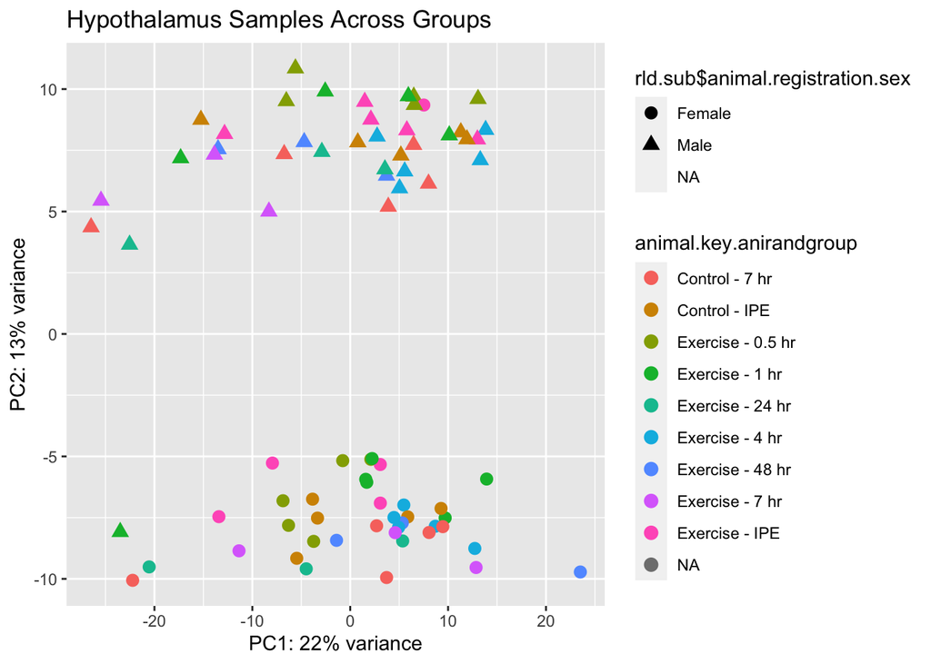

```r
# subset the dataset to only Gastro, which is my tissue of interest
rld.sub <- rld[ , (rld$Tissue == "Hypothalamus") ]
# rld.sub = rld.sub[, -is.na(rld.sub$animal.registration.sex)]
# rld.sub = rld.sub[, (rld.sub$animal.registration.sex == "Male")]

pcaData <- DESeq2::plotPCA(rld.sub, intgroup=c("animal.key.anirandgroup","hour_death"), returnData=TRUE)
percentVar <- round(100 * attr(pcaData, "percentVar"))
ggplot(pcaData, aes(PC1, PC2, color=animal.key.anirandgroup, shape = rld.sub$animal.registration.sex)) +
  geom_point(size=3) +
  #geom_text(aes(label=Tissue),hjust=0, vjust=0) +
  xlab(paste0("PC1: ",percentVar[1],"% variance")) +
  ylab(paste0("PC2: ",percentVar[2],"% variance")) +
  #coord_fixed() +
  ggtitle("Hypothalamus Samples Across Groups")
```

```r
# visualize the distribution of PCs' variance explained
pcaData_1 = prcomp(t(assay(rld.sub)))
summary(pcaData_1)
```

```
## Importance of components:
##                            PC1     PC2     PC3     PC4     PC5     PC6     PC7
## Standard deviation     14.9401 10.2792 8.79846 7.69779 6.51872 6.18381 5.81499
## Proportion of Variance  0.1519  0.0719 0.05268 0.04032 0.02892 0.02602 0.02301
## Cumulative Proportion   0.1519  0.2238 0.27646 0.31678 0.34570 0.37172 0.39473
##                            PC8     PC9   PC10   PC11    PC12    PC13    PC14
## Standard deviation     5.30375 5.07961 4.9840 4.8038 4.73779 4.57475 4.52610
## Proportion of Variance 0.01914 0.01756 0.0169 0.0157 0.01527 0.01424 0.01394
## Cumulative Proportion  0.41387 0.43143 0.4483 0.4640 0.47930 0.49355 0.50749
##                           PC15    PC16    PC17    PC18    PC19    PC20    PC21
## Standard deviation     4.38935 4.26678 4.16656 4.06730 4.05462 3.98955 3.95213
## Proportion of Variance 0.01311 0.01239 0.01181 0.01126 0.01119 0.01083 0.01063
## Cumulative Proportion  0.52060 0.53298 0.54480 0.55605 0.56724 0.57807 0.58870
##                          PC22    PC23    PC24    PC25    PC26    PC27    PC28
## Standard deviation     3.9288 3.88328 3.80863 3.76318 3.73977 3.72929 3.68823
## Proportion of Variance 0.0105 0.01026 0.00987 0.00964 0.00952 0.00946 0.00926
## Cumulative Proportion  0.5992 0.60946 0.61933 0.62897 0.63849 0.64795 0.65721
##                           PC29   PC30    PC31    PC32    PC33    PC34    PC35
## Standard deviation     3.68150 3.6172 3.59846 3.58207 3.55648 3.51454 3.50358
## Proportion of Variance 0.00922 0.0089 0.00881 0.00873 0.00861 0.00841 0.00835
## Cumulative Proportion  0.66643 0.6753 0.68415 0.69288 0.70148 0.70989 0.71824
##                           PC36    PC37    PC38   PC39    PC40    PC41    PC42
## Standard deviation     3.49587 3.45600 3.44649 3.4064 3.39841 3.36716 3.33559
## Proportion of Variance 0.00832 0.00813 0.00808 0.0079 0.00786 0.00771 0.00757
## Cumulative Proportion  0.72656 0.73468 0.74277 0.7507 0.75852 0.76624 0.77381
##                           PC43    PC44    PC45    PC46    PC47    PC48    PC49
## Standard deviation     3.31330 3.28181 3.26970 3.24558 3.23655 3.22043 3.18786
## Proportion of Variance 0.00747 0.00733 0.00727 0.00717 0.00713 0.00706 0.00692
## Cumulative Proportion  0.78128 0.78861 0.79588 0.80305 0.81018 0.81723 0.82415
##                           PC50    PC51    PC52    PC53    PC54   PC55    PC56
## Standard deviation     3.17411 3.15992 3.13343 3.10999 3.09502 3.0914 3.07970
## Proportion of Variance 0.00686 0.00679 0.00668 0.00658 0.00652 0.0065 0.00645
## Cumulative Proportion  0.83101 0.83780 0.84448 0.85106 0.85758 0.8641 0.87054
##                           PC57    PC58   PC59    PC60    PC61    PC62    PC63
## Standard deviation     3.07080 3.06182 3.0188 3.01440 3.00551 2.98470 2.97797
## Proportion of Variance 0.00642 0.00638 0.0062 0.00618 0.00615 0.00606 0.00603
## Cumulative Proportion  0.87695 0.88333 0.8895 0.89572 0.90186 0.90793 0.91396
##                           PC64    PC65    PC66    PC67    PC68    PC69    PC70
## Standard deviation     2.96577 2.92597 2.91291 2.90649 2.87969 2.87523 2.86227
## Proportion of Variance 0.00599 0.00583 0.00577 0.00575 0.00564 0.00563 0.00557
## Cumulative Proportion  0.91995 0.92577 0.93155 0.93729 0.94294 0.94856 0.95414
##                           PC71    PC72    PC73    PC74    PC75    PC76    PC77
## Standard deviation     2.84886 2.79738 2.79479 2.76804 2.75454 2.70019 2.67706
## Proportion of Variance 0.00552 0.00532 0.00531 0.00521 0.00516 0.00496 0.00488
## Cumulative Proportion  0.95966 0.96498 0.97030 0.97551 0.98068 0.98564 0.99051
##                          PC78    PC79      PC80
## Standard deviation     2.6557 2.62440 6.327e-14
## Proportion of Variance 0.0048 0.00469 0.000e+00
## Cumulative Proportion  0.9953 1.00000 1.000e+00
```

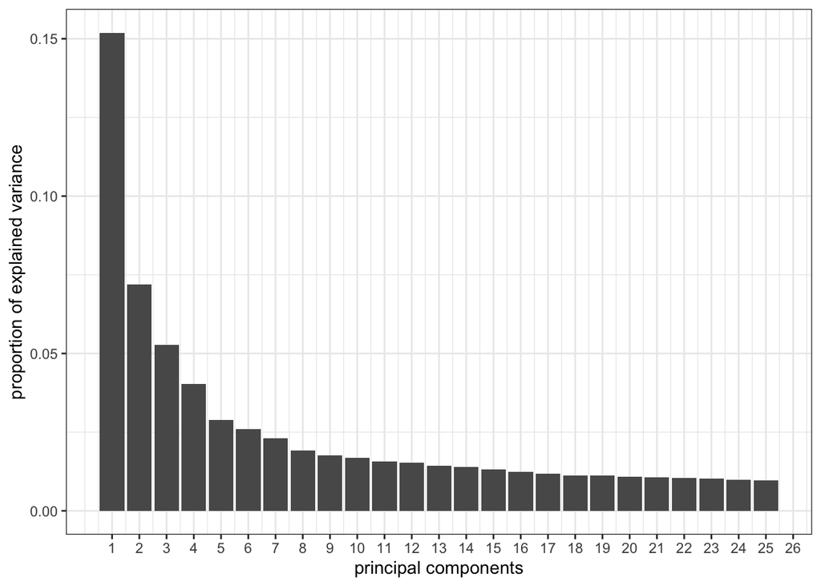

```r
pcascree(pcaData_1, pc_nr = 25, type = "pev")
```

## Defferential gene expression

### Modeling raw counts with normalization

now perform *differential gene expression* on the counts, try to find genes with dfference in counts across groups due to the condition of interest rises above the biological and technical variance we observe

```r
# variables in design formula cannot contain NA, so I have to remove ref samples here
count_data = sford_2[, sort(colnames(sford_2))]
col_data = status[sort(rownames(status)), ]
count_data = count_data[,-which(is.na(col_data$animal.key.anirandgroup))]
col_data = col_data[-which(is.na(col_data$animal.key.anirandgroup)),]
count_data = count_data[,-which(col_data$Tissue != "Hypothalamus")]
col_data = col_data[-which(col_data$Tissue != "Hypothalamus"), ]
#group = col_data$animal.key.anirandgroup
#design = ~ col_data$animal.key.anirandgroup
title = paste0('Design: ',as.character(design))
# Create a DESeqDataSet Object
dds <- DESeqDataSetFromMatrix(countData = count_data,
                              colData = col_data,
                              design = ~ animal.key.anirandgroup)


# Filter genes with average count of 10 or less. (this time I won't perform this)
# Reasoning from:
#citation("PROPER")
#dds
# keep <- rowMeans(counts(dds)) >= 10
# dds <- dds[keep,]

dds_1 <- estimateSizeFactors(dds)
rs <- rowSums(counts(dds_1))
# Normalize the counts
rld <- vst(dds_1) #vst and rlog comparable with all samples
#rld <- rlog(dds, blind=FALSE)

# Extract matrix of normalized counts
norm_counts <- assay(rld)
counts <- as.data.frame(norm_counts)

# Annotate normalized counts
counts$ensembl <- rownames(counts)
counts$symbol <- mapIds(org.Rn.eg.db, counts$ensembl, "SYMBOL", "ENSEMBL")
counts$entrez <- mapIds(org.Rn.eg.db, counts$ensembl, "ENTREZID", "ENSEMBL")
counts$genename <- mapIds(org.Rn.eg.db, counts$ensembl, "GENENAME", "ENSEMBL")
counts$go <- mapIds(org.Rn.eg.db, counts$ensembl, "GO", "ENSEMBL")
counts$path <- mapIds(org.Rn.eg.db, counts$ensembl, "PATH", "ENSEMBL")

#
```

Then run the DESeq2 model:

```r
dds <- DESeq(dds)
res = results(dds)
head(res)
```

```
## log2 fold change (MLE): animal.key.anirandgroup Exercise...IPE vs Control...7.hr
## Wald test p-value: animal.key.anirandgroup Exercise...IPE vs Control...7.hr
## DataFrame with 6 rows and 6 columns
##                            baseMean      log2FoldChange              lfcSE
##                           <numeric>           <numeric>          <numeric>
## ENSRNOG00000000001 4.07350170765388   0.231271581463379  0.422482359494974
## ENSRNOG00000000007 5744.61309526082 -0.0174823373636754 0.0627020462009218
## ENSRNOG00000000008 15.8029040200894  -0.257296530992205  0.541223918142013
## ENSRNOG00000000009 1.16959513656335   0.494486141320397  0.856155108411418
## ENSRNOG00000000010 3015.59299379264  -0.120183602877486 0.0920062245245025
## ENSRNOG00000000012 19.8775020541882 -0.0463781137538398  0.202312870604907
##                                  stat            pvalue              padj
##                             <numeric>         <numeric>         <numeric>
## ENSRNOG00000000001  0.547411214375522 0.584096252524884 0.873657505964712
## ENSRNOG00000000007 -0.278816058213718 0.780385990288521 0.948043372141913
## ENSRNOG00000000008 -0.475397561651538 0.634503632111773  0.89830441075221
## ENSRNOG00000000009  0.577566070052316 0.563557119972503                NA
## ENSRNOG00000000010  -1.30625513109147 0.191465810077132  0.59729618004465
## ENSRNOG00000000012  -0.22923956155222 0.818682725485532 0.958836665244307
```

**for myself reference** Another way to look at the difference is that a p-value of 0.05 implies that 5% of all tests  
will result in false positives. An FDR adjusted p-value (or q-value) of 0.05 implies that 5%  
of significant tests will result in false positives. The latter will result in fewer false  
positives.

```r
# table(res$padj < 0.1)
# summary(res)
#which()
res2 <- results(dds, alpha=0.05)
table(res2$padj < 0.05)
```

```
##
## FALSE  TRUE
## 16344   689
```

```r
# a sorted results table:
resSort <- res2[order(res2$padj),]
```

### Visualizing results

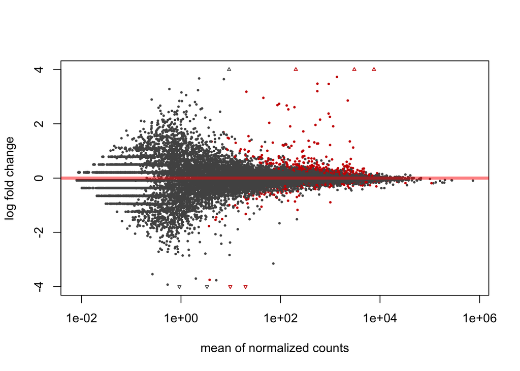

```r
plotMA(res2, ylim=c(-4,4), alpha = 0.05)
```

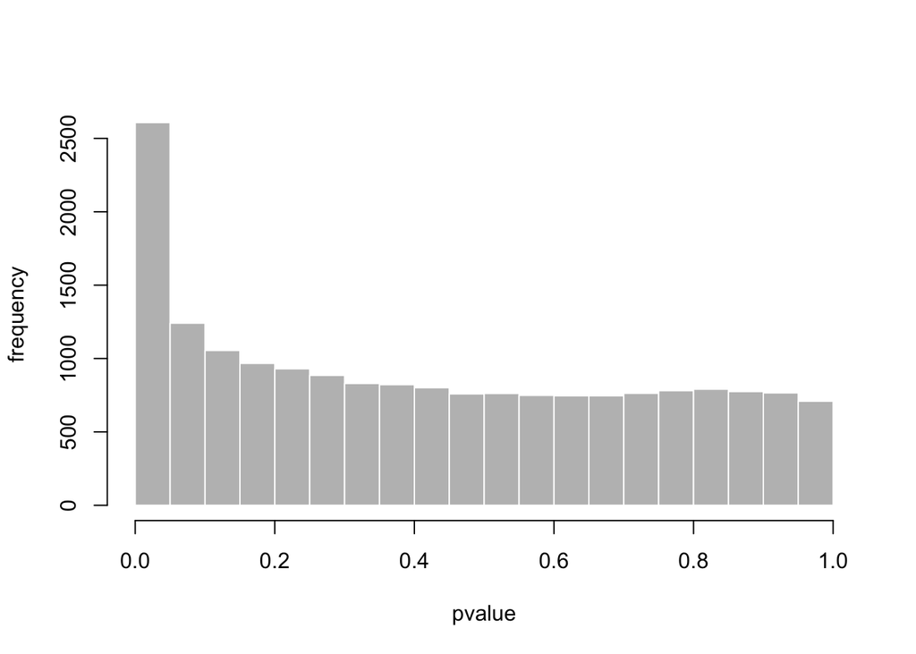

```r
hist(res2$pvalue[res2$baseMean > 1],
     col="grey", border="white", xlab="pvalue", ylab="frequency", main="")
```

Examine the counts for the top gene, sorting by FDR:

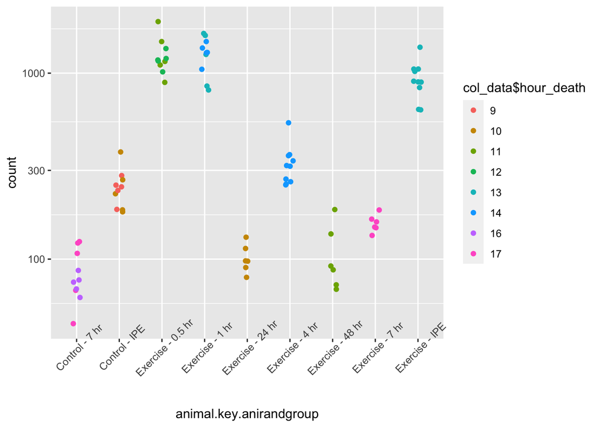

```r
#plotCounts(dds, gene=which.min(res2$padj), intgroup="animal.key.anirandgroup")
data <- plotCounts(dds, gene=which.min(res2$padj), intgroup="animal.key.anirandgroup", returnData=TRUE)
ggplot(data, aes(x=animal.key.anirandgroup, y=count, col = col_data$hour_death)) +
  geom_point(position=position_jitter(width=.1,height=0)) +
  #stat_smooth() +
  scale_y_log10() +
  theme(axis.text.x = element_text(angle = 45))
```

```r
#which gene it is
counts[which.min(res2$padj),c("symbol","genename")]
```

```
##                    symbol
## ENSRNOG00000046667   Fosb
##                                                                  genename
## ENSRNOG00000046667 FosB proto-oncogene, AP-1 transcription factor subunit
```

Draw heatmap of the top genes:

[figure not shown]

```r
topgenes <- head(rownames(resSort),20)
mat <- assay(rld)[topgenes,]

# standarized the count matrix
mat <- mat - rowMeans(mat)
df <- as.data.frame(colData(dds)[,"animal.key.anirandgroup"])
rownames(df) = colnames(mat)
pheatmap(mat, annotation_col=df)
```

As we talked in meeting, the control-7 group and exercise-7 group are well matched  
So I try to find genes that are significantly differently expressed in those 2 groups

```r
res3 <- results(dds, alpha=0.05, contrast = c("animal.key.anirandgroup", "Control - 7 hr", "Exercise - 7 hr"))
table(res3$padj < 0.05)
```

```
##
## FALSE  TRUE
## 16510    57
```

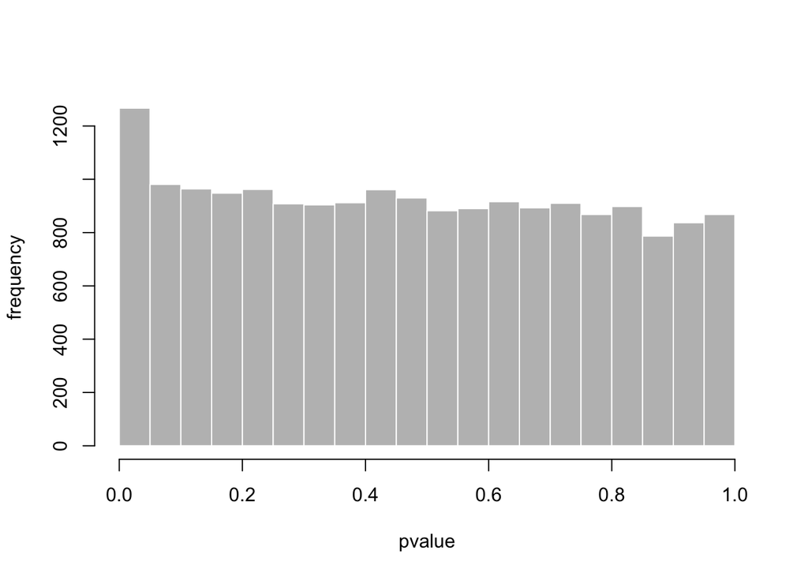

```r
hist(res3$pvalue[res3$baseMean > 1],
     col="grey", border="white", xlab="pvalue", ylab="frequency", main="")
```

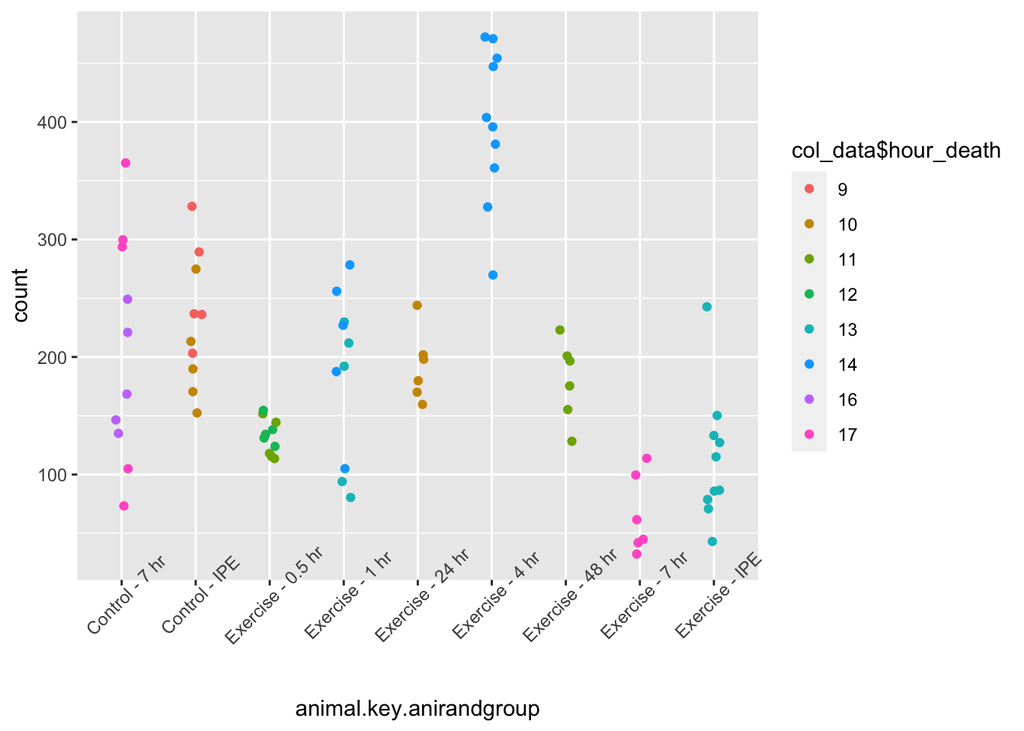

```r
data <- plotCounts(dds, gene=which.min(res3$padj), intgroup="animal.key.anirandgroup", returnData=TRUE)
ggplot(data, aes(x=animal.key.anirandgroup, y=count, col = col_data$hour_death)) +
  geom_point(position=position_jitter(width=.1,height=0)) +
  #scale_y_log10() +
  theme(axis.text.x = element_text(angle = 45))
```

```r
counts[which.min(res3$padj),c("symbol","genename")]
```

```
##                    symbol                                 genename
## ENSRNOG00000017198  Hif3a hypoxia inducible factor 3 subunit alpha
```

Also draw a heatmap for the top DE genes in the control-7 group vs the exercise-7 group:

[figure not shown]

```r
resSort_7 <- res3[order(res3$padj),]
topgenes_7 <- head(rownames(resSort_7),20)
mat <- assay(rld)[topgenes_7,]

# standarized the count matrix
mat <- mat - rowMeans(mat)
pheatmap(mat, annotation_col=df)
```